# A01212611_thermo_Hwk04

Q4001 Thermodynamics of Materials  
Homework 4  
Osamu Katagiri - A01212611@itesm.mx - CEM

```python
#******************************************************************************#
# Futures
%matplotlib inline
# from __future__ import unicode_literals
# from __future__ import print_function

# Generic/Built-in
import datetime
import argparse

# Other Libs
from IPython.display import display, Image
from sympy import *
import matplotlib.pyplot as plt
import numpy as np

# Owned
# from nostalgia_util import log_utils
# from nostalgia_util import settings_util
__authors__   = ["Osamu Katagiri - A01212611@itesm.mx"]
__copyright__ = "None"
__credits__   = ["Marcelo Videa - mvidea@itesm.mx"]
__license__   = "None"
__status__    = "Under Work"
#******************************************************************************#
```

## Exercise 1 & 2

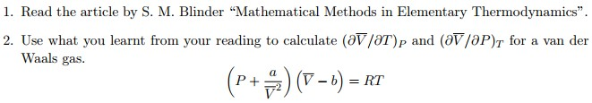

```python
display(Image(filename='./directions/1_2.jpg'))
```

Blinder, S. M. (1966). Mathematical methods in elementary thermodynamics. Journal of Chemical Education, 43(2), 85. https://doi.org/10.1021/ed043p85 https://github.com/WolframResearch/WolframLanguageForJupyter

### Exercise 1 & 2 - part A

Let's calculate $$ \left(\frac{\partial V}{\partial T}\right)_P $$ from $$ dP=\left(\frac{\partial P}{\partial V}\right)_TdV+\left(\frac{\partial P}{\partial T}\right)_VdT $$ supposing that $$ P(V, T)=constant $$ so that $$ dP=0 $$ if $$ \left(\frac{\partial P}{\partial V}\right)_TdV+\left(\frac{\partial P}{\partial T}\right)_VdT=0 $$ then $$ \left(\frac{\partial V}{\partial T}\right)_P=-\frac{\left(\frac{\partial P}{\partial T}\right)_V}{\left(\frac{\partial P}{\partial V}\right)_T} $$

Let's use Mathematica to compute $$ \left(\frac{\partial P}{\partial V}\right)_T $$

```python
D[Solve[(P + a/V^2)*(V - b) == R*T, P], V] //ToRadicals //First //First //FullSimplify
```

Let's compute $$ \left(\frac{\partial P}{\partial T}\right)_V $$

```python
D[Solve[(P + a/V^2)*(V - b) == R*T, P], T] //ToRadicals //First //First //FullSimplify
```

Let's compute $$ \left(\frac{\partial V}{\partial T}\right)_P $$

```python
-(R/(-b + V))/(-((R T)/(b - V)^2) + (2 a)/V^3) //ToRadicals //FullSimplify
```

$$ \left(\frac{\partial V}{\partial T}\right)_P = \frac{R V^3 (V-b)}{-2 a (b-V)^2 + R T V^3} $$

### Exercise 1 & 2 - part B

Let's calculate $$ \left(\frac{\partial V}{\partial P}\right)_T $$ from $$ dP=\left(\frac{\partial T}{\partial V}\right)_PdV+\left(\frac{\partial T}{\partial P}\right)_VdP $$ supposing that $$ T(V, P)=constant $$ so that $$ dT=0 $$ if $$ \left(\frac{\partial T}{\partial V}\right)_PdV+\left(\frac{\partial T}{\partial P}\right)_VdP=0 $$ then $$ \left(\frac{\partial V}{\partial P}\right)_T=-\frac{\left(\frac{\partial T}{\partial P}\right)_V}{\left(\frac{\partial T}{\partial V}\right)_P} $$

Let's use Mathematica to compute $$ \left(\frac{\partial T}{\partial V}\right)_P $$

```python
D[Solve[(P + a/V^2)*(V - b) == R*T, T], V] //ToRadicals //First //First //FullSimplify
```

Let's compute $$ \left(\frac{\partial T}{\partial P}\right)_V $$

```python
D[Solve[(P + a/V^2)*(V - b) == R*T, T], P] //ToRadicals //First //First //FullSimplify
```

Let's compute $$ \left(\frac{\partial V}{\partial P}\right)_T $$

```python
-((-b + V)/R)/((2 a b - a V + P V^3)/(R V^3)) //ToRadicals //FullSimplify
```

$$ \left(\frac{\partial V}{\partial P}\right)_T = \frac{(b-V) V^3}{2 a b - a V + P V^3} $$

## Exercise 3

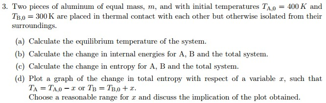

```python
display(Image(filename='./directions/3.jpg'))
```

### Exercise 3 - part A

The heat transferred from the hot to the cold aluminum piece $dq_{h \rightarrow c}$ is equal to the heat adsorbed by the cold from the hot $dq_{c \rightarrow h}$ after they reach the final temperature, $T_f$. $dq_{h \rightarrow c} = -dq_{c \rightarrow h}$  
also, if $m$ is the mass of aluminium, then $n = \frac{m}{M}$; where $M$ is the atomic weight of aluminium.  
$T_h = T_{A,0} = 400 K$  
$T_c = T_{B,0} = 300 K$

Let's asume $C_p = 0.91 J g^{-1} K^{-1}$, $m = 1 Kg$ and $M = 26.982 g mol^{-1}$.  
Therefore, $n = 37.062 mol$

Since $ dq = C_pdT = n\bar{C_p}dT $, the following can be done: $$ C_{p_{cold}}dT = -C_{p_{hot}}dT $$ $$ n \int_{T_c}^{T_f} \overline{C_{p_{\text{Al}}}} \, dT+n \int_{T_h}^{T_f} \overline{C_{p_{\text{Al}}}} \, dT=0 $$ $$ n \left(T_f-T_c\right) \overline{C_{p_{\text{Al}}}}+n \left(T_f-T_h\right) \overline{C_{p_{\text{Al}}}} = 0 $$ $$ T_f = \frac{1}{2} \left(T_c+T_h\right) $$ $$ T_f = \frac{1}{2} \left(300 K+400 K\right) $$

$$ T_f = 350 K $$

### Exercise 3 - part B for A

$$ \Delta U_{A} = C_{p_{hot}}dT $$$$ \Delta U_{A} = C_{p_{hot}}(350 K - 400 K) $$

$$ \Delta U_{A} = (-50 K)C_{p_{hot}} $$ $$ \Delta U_{A} = (-50 K)(0.91 J g^{-1} K^{-1}) = -45.5 Jg^{-1} $$ $$ \Delta U_{A} = -45500 J $$

### Exercise 3 - part B for B

$$ \Delta U_{B} = C_{p_{cold}}dT $$$$ \Delta U_{B} = C_{p_{cold}}(350 K - 300 K) $$

$$ \Delta U_{B} = (50 K)C_{p_{cold}} $$ $$ \Delta U_{B} = (50 K)(0.91 J g^{-1} K^{-1}) = 45.5Jg^{-1} $$ $$ \Delta U_{B} = 45500J $$

### Exercise 3 - part B for the total system

$$ \Delta U_{isolatedSystem} = 0 $$

Since energy is a conserved quantity.

### Exercise 3 - part C for A

$$ \text{dS}_{A}=n \overline{C_{p_{\text{Al}}}} \int_{T_h}^{T_f} \frac{1}{T} \, dT $$$$ \text{dS}_{A}=n \overline{C_{p_{\text{Al}}}} ln \left(\frac{T_f}{T_h}\right) $$$$ \text{dS}_{A}=(1000 g) (0.91 J g^{-1} K^{-1}) ln \left(\frac{350 K}{400 K}\right) $$

$$ \text{dS}_{A}=-121.514 J K^{-1} $$

### Exercise 3 - part C for B

$$ \text{dS}_{B}=n \overline{C_{p_{\text{Al}}}} \int_{T_c}^{T_f} \frac{1}{T} \, dT $$$$ \text{dS}_{B}=n \overline{C_{p_{\text{Al}}}} ln \left(\frac{T_f}{T_c}\right) $$$$ \text{dS}_{B}=(1000 g) (0.91 J g^{-1} K^{-1}) ln \left(\frac{350 K}{300 K}\right) $$

$$ \text{dS}_{B}=140.277 J K^{-1} $$

### Exercise 3 - part C for the total system

The total change in entropy for the system is given by the sum of the change in entropy for the hot block and the cold block. $$ \text{dS}_{isolatedSystem}=n \overline{C_{p_{\text{Al}}}} \int_{T_c}^{T_f} \frac{1}{T} \, dT+n \overline{C_{p_{\text{Al}}}} \int_{T_h}^{T_f} \frac{1}{T} \, dT $$ $$ \text{dS}_{isolatedSystem}=dS_A+dS_B $$

$$ \text{dS}_{isolatedSystem}= -121.514 J K^{-1} + 140.277 J K^{-1} = 18.763 J K^{-1}$$

### Exercise 3 - part D

$$ \Delta S = n C_p ln\left(\frac{T_f}{T_i}\right) $$

where: $$ T_f = T_i - x \text{ for A; & }T_f = T_i + x \text{ for B;} $$

```
<module 'matplotlib.pyplot' from 'C:\\Users\\oskat\\Anaconda3\\lib\\site-packages\\matplotlib\\pyplot.py'>
```

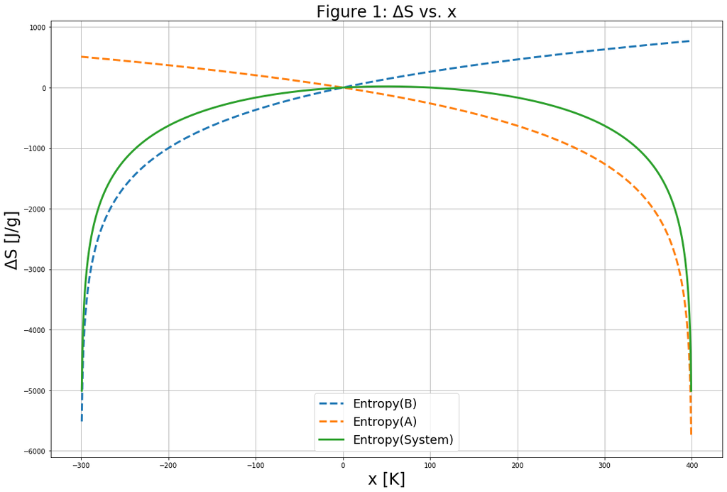

```python
# Function to compute the "next" pressure value for IRREVERSIBLE processes
def S_A_(n, Cp, Ti, x):
    Tf = Ti - x;
    return n*Cp*(np.log(Tf/Ti));

def S_B_(n, Cp, Ti, x):
    Tf = Ti + x;
    return n*Cp*(np.log(Tf/Ti));

# Draw the plot's workspace
scale = 6;
plt.subplots(figsize=(3*scale, 2*scale))

# define constants
n = 1000 #g or 37.062 mol
Cp = 0.91 #J / g K
Tmin = -300 #K
Tmax = 400 #K
Tequi = 350 #K
x = np.linspace(Tmin, Tmax, 1000);

# for B
Ti_B = 300 #K
S_B = S_B_(n, Cp, Ti_B, x)
plt.plot(x, S_B, '--', linewidth=3, label='Entropy(B)');

# for A
Ti_A = 400 #K
S_A = S_A_(n, Cp, Ti_A, x)
#print(S_A)
plt.plot(x, S_A, '--', linewidth=3, label='Entropy(A)');

# for A+B
plt.plot(x, (S_A+S_B), '-', linewidth=3, label='Entropy(System)');

plt.xlabel('x [K]', fontsize=24);
plt.ylabel('ΔS [J/g]', fontsize=24);
plt.title("Figure 1: ΔS vs. x", size=24)
plt.legend(prop={'size': 18})
plt.grid('on')
display(plt);
```

## Exercise 4

```python
display(Image(filename='./directions/4.jpg'))
```

[output not shown]

### Problem 4 - Hwk 02

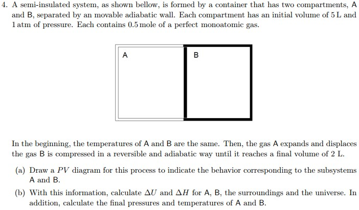

```python
display(Image(filename='./directions/4_1.jpg'))
```

Process A is some kind of expansion; & Process B is an Adiabatic compression.  
The pressures are always the same, since the process is reversible. -> The system is always in a state of equilibrium.

### Problem 4 - For B

Initial Temperature $$ T_{i_B} = P_{i_B} V_{i_B} n^{-1} R^{-1} $$ $$ T_{i_B} = \frac{(1 atm)(5L)}{(0.5 mol)(0.08206 atm L K^{-1} mol^{-1})} $$ $$ T_{i_B} = 121.862 K $$

Final pressure
As B is dealing with an monoatomic gas, $C_v = \frac{3}{2}R$ & $\gamma = \frac{5}{3}$ $$ P_{i_B} {V_{i_B}}^{\gamma} = P_{f_B} {V_{f_B}}^{\gamma} $$ $$ P_{f_B} = \frac{P_{i_B} {V_{i_B}}^{\gamma}}{{V_{f_B}}^{\gamma}} $$ $$ P_{f_B} = \frac{(1 atm) {(5 L)}^{\frac{5}{3}}}{{(2 L)}^{\frac{5}{3}}} $$ $$ P_{f_B} = 4.605 atm = 466602 Pa $$

Final Temperature $$ T_{f_B} = \frac{P_{f_B} V_{f_B}}{n R} $$ $$ T_{f_B} = \frac{(4.605 atm)(2 L)}{(0.5 mol)(0.08206 atm L K^{-1} mol^{-1})} $$ $$ T_{f_B} = 224.4699 K $$

Internal energy $$ \Delta U_B = Q_B - W_B $$ where $Q_B = 0$, and for adiabatic processes, $$ W_B = \frac{P_{f_B}V_{f_B} - P_{i_B}V_{i_B}}{\gamma - 1} $$ $$ W_B = \frac{(4.605 atm)(2 L) - (1 atm)(5 L)}{\frac{5}{3} - 1} $$ $$ W_B = 6.315 atm L = 639.709 J $$ $$ \Delta U_B = -639.709 J $$

Entropy for adiabatic processes is:

$$ \Delta S_B = 0 J K^{-1} $$

### Problem 4 - For A

Initial temperature $$ T_{i_A} = T_{i_B} = 121.862 K $$

Final pressure $$ P_{f_A} = P_{f_B} = 4.605 atm = 466602 Pa $$

Final temperature $$ T_{f_A} = \frac{P_{f_A} V_{f_A}}{n R} $$ $$ T_{f_A} = \frac{(4.605 atm)(8 L)}{(0.5 mol)(0.08206 atm L K^{-1} mol^{-1})} $$ $$ T_{f_A} = 897.8796 K $$

Internal energy $$ \Delta U_A = n C_v \Delta T_A $$ $$ \Delta U_A = (0.5 mol)\left(\frac{3R}{2}\right)(897.8796 K - 121.862 K) $$ $$ \Delta U_A = 4839.127 J $$

Entropy $$ dU = T dS - P dV $$ $$ dS = \frac{1}{T} dU + \frac{P}{T} dV $$ $$ \Delta S_A = \frac{1}{T_{f_A}} \Delta U_A + \frac{P_{f_A}}{T_{f_A}} (V_{f_A} - V_{i_A}) $$ $$ \Delta S_A = \frac{1}{897.8796 K} (4839.127 J) + \frac{466602 Pa}{897.8796 K} (8 L - 5 L) $$

$$ \Delta S_A = 6.948 J K^{-1} $$

### Problem 4 - For the Surroundings and the Universe

Internal Energy $$ \Delta U_{universe} = 0 J $$ $$ \Delta U_{universe} = \Delta U_A + \Delta U_B + \Delta U_{surroundings} $$ $$ \Delta U_{surroundings} = - \Delta U_A - \Delta U_B $$ $$ \Delta U_{surroundings} = - 4839.127 J - (-639.709 J) $$ $$ \Delta U_{surroundings} = -4199.418 J $$

Entropy

$$ \Delta S_{universe} = 0 J K^{-1} $$

$$ \Delta S_{universe} = \Delta S_A + \Delta S_B + \Delta S_{surroundings} $$ $$ \Delta S_{surroundings} = - \Delta S_A - \Delta S_B $$ $$ \Delta S_{surroundings} = -6.948 J K^{-1} -0 J K^{-1} $$

$$ \Delta S_{surroundings} = -6.948 J K^{-1} $$

```
<module 'matplotlib.pyplot' from 'C:\\Users\\oskat\\Anaconda3\\lib\\site-packages\\matplotlib\\pyplot.py'>
```

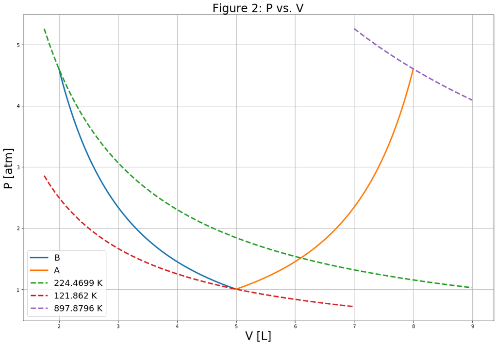

```python
# Function to compute the "next" pressure value
def P_p_(Pi, Vi, Vf, gamma):
    return (Pi*Vi**gamma)/(Vf**gamma);

def P_(Tf, n, R, Vf):
    return (Tf*n*R)/(Vf);

# Draw the plot's workspace
scale = 6;
plt.subplots(figsize=(3*scale, 2*scale))

# For P_B
Pi = 1 #atm
Vi = 5 #L
Vf = 2 #L
gamma = 5/3
V = np.linspace(Vi,Vf,1000);
P_B = P_p_(Pi, Vi, V, gamma)
plt.plot(V, P_B, '-', linewidth=3, label='B');

# For P_A
Pi = 1 #atm
Vi = 5 #L
Vf = 8 #L
gamma = 1
V = np.linspace(Vi,Vf,1000);
P_A = P_p_(Pi, Vi, V, gamma)
plt.plot(V, P_B, '-', linewidth=3, label='A');

# For Temps
n = 0.5 #mol
R = 0.08206 #atm L / K mol

Tf = 224.4699 #K
Vi = 1.75 #L
Vf = 9 #L
V = np.linspace(Vi,Vf,1000);
P = P_(Tf, n, R, V)
plt.plot(V, P, '--', linewidth=3, label='224.4699 K');

Tf = 121.862 #K
Vi = 1.75 #L
Vf = 7 #L
V = np.linspace(Vi,Vf,1000);
P = P_(Tf, n, R, V)
plt.plot(V, P, '--', linewidth=3, label='121.862 K');

Tf = 897.8796 #K
Vi = 7 #L
Vf = 9 #L
V = np.linspace(Vi,Vf,1000);
P = P_(Tf, n, R, V)
plt.plot(V, P, '--', linewidth=3, label='897.8796 K');

plt.xlabel('V [L]', fontsize=24);
plt.ylabel('P [atm]', fontsize=24);
plt.title("Figure 2: P vs. V", size=24)
plt.legend(prop={'size': 18})
plt.grid('on')
display(plt);
```

## Exercise 5

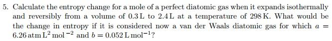

```python
display(Image(filename='./directions/5.jpg'))
```

For Isothermic Processes, $$ ds = \frac{P}{T} dV = n R \frac{dV}{V} $$ $$ \Delta S = n R ln \left(\frac{V_f}{V_i}\right) $$ $$ \Delta S = (1 mol) (8.314 J K^{-1} mol^{-1}) ln \left(\frac{2.4 L}{0.3 L}\right) $$

$$ \Delta S = 17.289 J K^{-1} $$

Considering a van der Waals diatomic gas, $$ \left(P + \frac{n^2 a}{V^2}\right)(V - n b) = n R T $$ $$ P = \frac{n R T}{V - n b} - \frac{n^2 a}{V^2} $$

Let's use the Maxwell relationship approach to determine the partial derivative of entropy. $$ \left(\frac{\partial S}{\partial V}\right)_T = \left(\frac{\partial P}{\partial T}\right)_V = \frac{n R}{V - n b}$$ $$ dS = \frac{n R}{V - n b} dV $$ $$ \Delta S = \int_{V_i}^{V_f} \frac{n R}{V-b n} \, dV $$ $$ \Delta S = n R \left[ ln(-n b + V_f) - ln(-n b + V_i) \right] $$ $$ \Delta S = (1 mol)(8.314 J K^{-1} mol^{-1})\left[ ln(-(1 mol)(0.052 L mol_{-1}) + 2.4 L) - ln(-(1 mol)(0.052 L mol_{-1}) + (0.3 L)) \right] $$

$$ \Delta S = 18.69 J K^{-1} $$

## Exercise 6

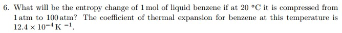

```python
display(Image(filename='./directions/6.jpg'))
```

$$ \rho_{benzene} = 874 g/L $$$$ M_{benzene} = 78.11 g/mol $$$$ \alpha_{benzene} = 12.4\times10^{-4} K^{-1}$$$$ C_{V_{benzene}} = 92.8 J K_{-1} mol_{-1} $$

Volume of 1 mol of liquid benzene: $$ \frac{874 g}{1 L} = \frac{78.11 g}{V_{benzene}} $$ $$ V_{benzene} = 0.0894 L $$

Let's use the Maxwell relationship approach to determine the partial derivative of entropy. $$ \left(\frac{\partial S}{\partial P}_T\right) = -\left(\frac{\partial V}{\partial T}_P\right) = -V \alpha $$ Knowing that $\alpha = \frac{1}{V} \left(\frac{\partial V}{\partial T}_P\right)$

## Exercise 7

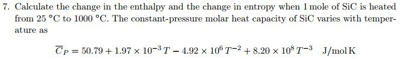

```python
display(Image(filename='./directions/7.jpg'))
```

$$ \Delta S_{SiC} = \int_{T_i}^{T_f} \frac{\text{$\delta $q}_{\text{rev}}}{T} \, dT=\int_{T_i}^{T_f} \frac{\text{$\delta $q}_P}{T} \, dT=\int_{25 \text{${}^{\circ}$C}}^{1000 \text{${}^{\circ}$C}} \frac{\text{nC}_{p_{\text{SiC}}}}{T} \, dT $$

As $n = 1 mol$, $$ \Delta S_{SiC} = \int_{25 \text{${}^{\circ}$C}}^{1000 \text{${}^{\circ}$C}} \frac{50.79\, +\frac{1.97 T}{10^3}-\frac{4.92 \times 10^6}{T^2}+\frac{8.2 \times 10^8}{T^3}}{T} \, dT $$ $$ \Delta S_{SiC} = \int_{25 \text{${}^{\circ}$C}}^{1000 \text{${}^{\circ}$C}} \frac{0.00197 T^4+50.79 T^3-4.92\times 10^6 T+8.2\times 10^8}{T^4} \, dT $$ $$ $$ $$ \Delta S_{SiC} = \left[\frac{2.73333 \times 10^8}{T^3} + \frac{2.46 \times 10^6}{T^2} + 0.00197 T + 50.79 ln(T)\right]_{T_i = 25 \text{${}^{\circ}$C} = 298.2 K}^{T_f = 1000 \text{${}^{\circ}$C} = 1273 K} $$

$$ \Delta S_{SiC} = (366.998 - 307.333) J K^{-1} = 59.6644 J K^{-1} $$

$$ \Delta H_{SiC} = \int_{T_i}^{T_f} \text{nC}_{p_{\text{SiC}}} \, dT $$$$ \Delta H_{SiC} = \int_{T_i = 25 \text{${}^{\circ}$C} = 298.2 K}^{T_f = 1000 \text{${}^{\circ}$C} = 1273 K} 50.79 +\frac{1.97 T}{10^3}-\frac{4.92 \times 10^6}{T^2}+\frac{8.2 \times 10^8}{T^3} \, dT $$$$ \Delta H_{SiC} = \left[-\frac{4.1 \times 10^8}{T^2} + \frac{4.92 \times 10^6}{T} + 50.79 T + 0.000985 T^2\right]_{T_i = 298.2 K}^{T_f = 1273 K} $$

$$ \Delta H_{SiC} = (69863.8 - 27121.4) J = 42742.3 J $$